# Analysis of Ford GoBike System Data

## by ( Tijani Ibraheem)

## Introduction

> This data set includes information about individual rides made in a bike-sharing system covering the greater San Francisco Bay area. The dataset has 16 original columns that contain some important columns relevant for our analysis and a few that are out of our question scopes

### Investigation Overview

- In this Ford GoBike dataset, the aim is to find out how users performed and for how long they ride on average. There are different users that makes use of the rental services. These users are of different genders and the aim and objective is to determine which gender has a longer average duration. Which day of the week and time of the day do we record the highest rides.

### Dataset Overview

- This data set includes information about individual rides made in a bike-sharing system covering the greater San Francisco Bay area. The dataset has 16 original columns that contain some important columns relevant for our analysis and a few that are out of our question scopes.

### Distribution of Bike ride duration in minutes

- The most frequent duration riders spent on bike hires are under 10 mins.

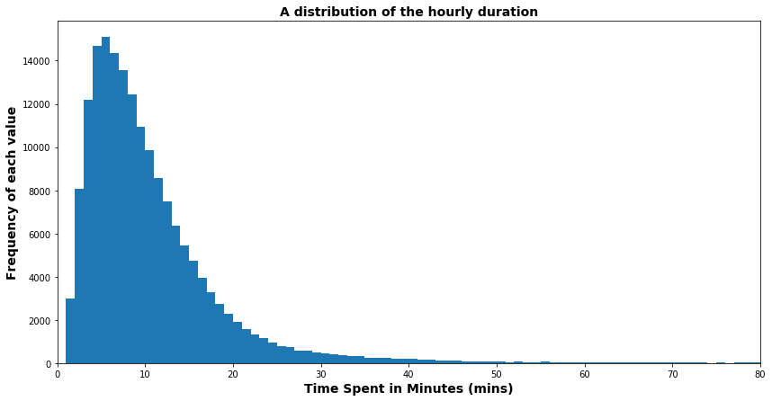

### Daily Distribution of rentals

- It is clear that weekends are not favorable on a general sense while weekdays have recorded the highest records especially Thursdays

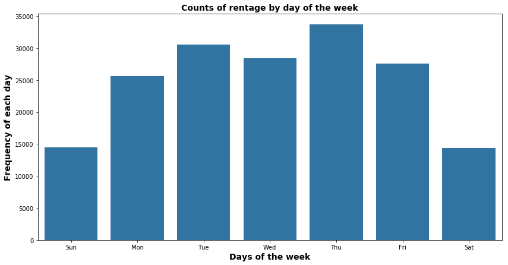

### Gender distribution by percentage

- Using a pie chart to assess the distribution of gender column, it is observed that, 75% of the customers that are males and 23% are females and just 2% Other gender. This can further be investigated later to know what user type they belong to.

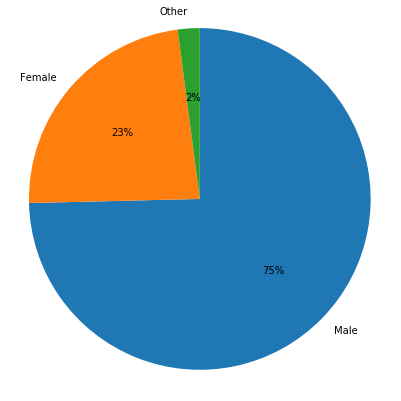

### What are the top departing 10 stations

- The busiest departing station is `Market St at 10th St` with over 3500 records.

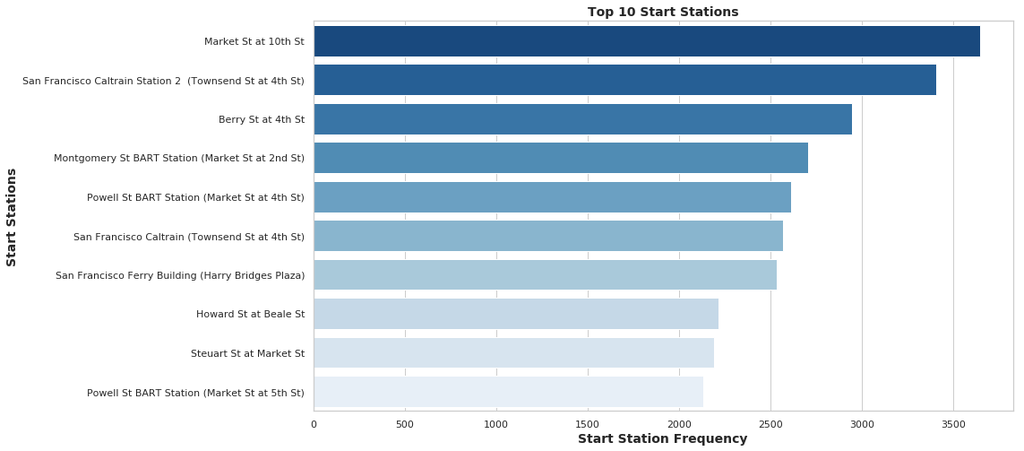

### What are the bottom departing 10 stations

- Some departing stations have a poor records. The least performing the stations are `16th St Depot`, `Palm St at Willlow St`, `21st Ave at International Bivd` with `2`,`3`,`4` respectively

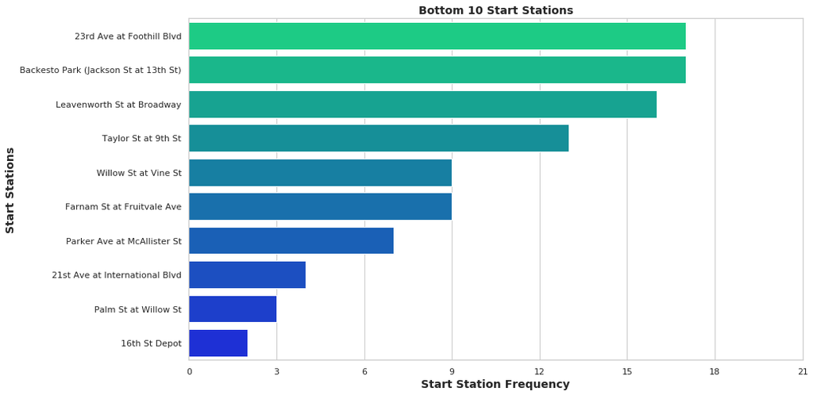

### What are the top destination 10 stations

- Among the ten most used stations for destination trips, we can see that, the `San Francisco Caltran Station 2(Townsend St at 4th St)` and the `Market St at 10th St` with almost `5000` and close to `4000` records respectively. This proves that, most users prefer to use the `San Francisco Caltran Station 2(Townsend St at 4th St)` as a destination stop more than the most used departing station.

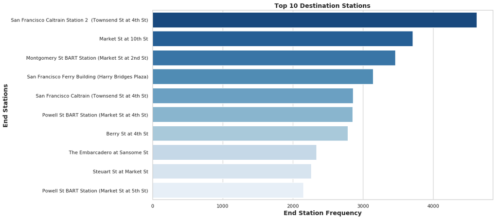

### What are the bottom 10 destination stations

- Some destination stations have a poor records. The least performing the stations are `16th St Depot`, `Willlow St at Vine St`, `21st Ave at International Bivd` with `4`,`4`,`5` respectively

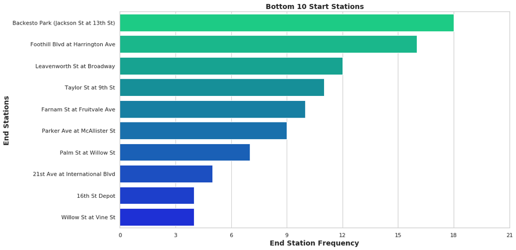

## Do we have a relationship between the age distribution and duration of ride?

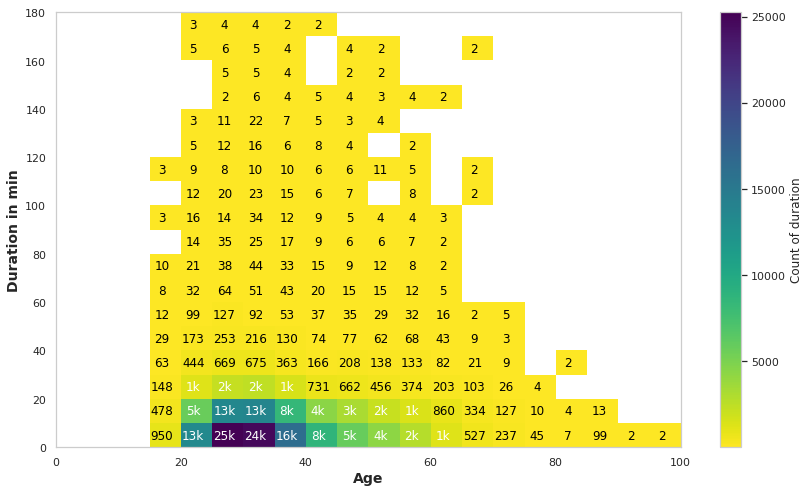

### How do user types compare to each other in terms of gender

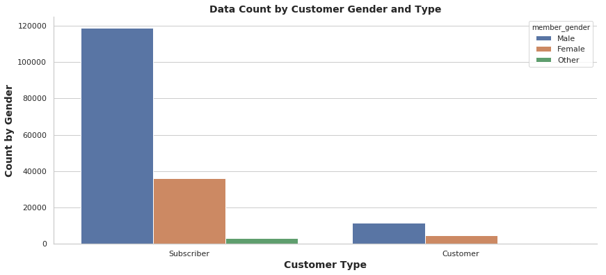

### How do Customers perform by Days of the week

- The plot below is an indication that, male customers always rent bikes more than any other gender anyday of the week. However, it can be seen that, weekends(Sat and Sun) record the lowest records in our data. This is because, customers don't usually go out over the weekend after a long day of work.

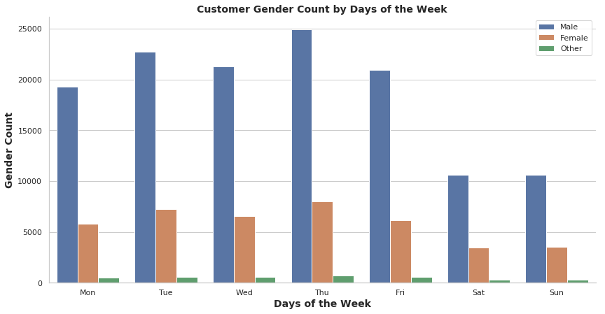

### For everyday that riders rent bikes, which day proved the busiest in the month of February

- The month with the highest minutes recorded was the last day of the month, 28th of February. The weekends of the 3rd and 9th have the lowest minutes. However a unique observation if the 13th, which is the only weekday with a ridiculously low records. This is the International Condoms Day, a day before Valentine's day. This could be coincidental, however, it's a nice point to observe.

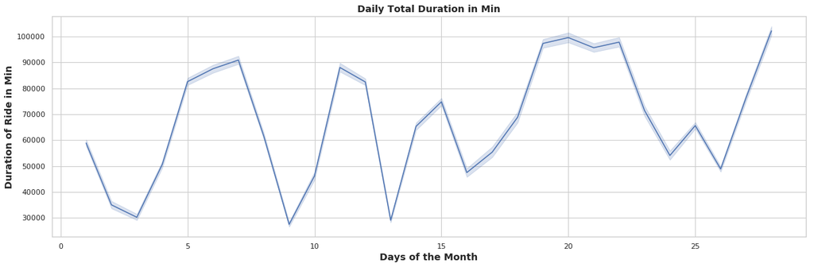

### Bike Ride Duration of all Genders by User Type

- On a general note, we can see as shown in the boxplot that, Customers user types have a higher duration ride than Subscriber user type. Furthermore, the female chart of the plot tell us that females spend longer with their rides.

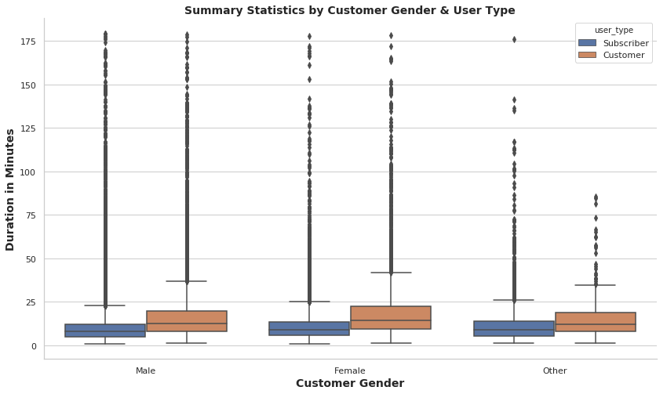

### User Types Performance by Demography

- The plot on the left is the average of the customers duration by age. But to determine how the data varies from the mean, we need to understand the variability and here is where the standard-deviation plot on the right comes in. There is close to zero deviation somewhere around the 75 years Customers and Subscribers. Customers aged 74 recorded the highest average duration of over 40 mins with a deviation of 14 mins. Subscribers on the other hand have their highest average riders in the age of 78 years with 28 mins ride and a deviation above 30 mins.

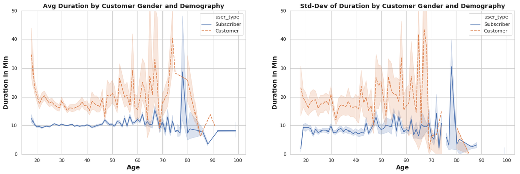

- The scatter plot below strenghtens the fact that, there is some huge deviation from the mean because we can see the huge distance between data points within the 60 years and 80 years old users. Generally, users duration ride decrease as they age.

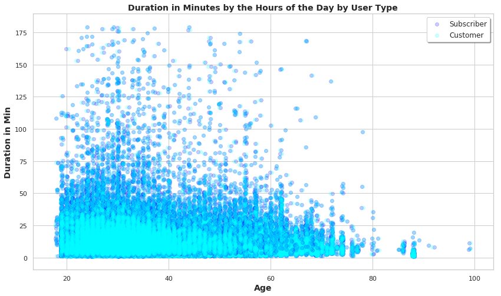

### What time of the day do we have the highest renatal activities?

- The peak total duration of the day occur at 8am and 5pm. This makes absolute sense because, since working days are the busiest days of the week, it only makes sense to see that, 8am when workers leave for work and 5pm when they return to their homes are the busiest durations of the week.

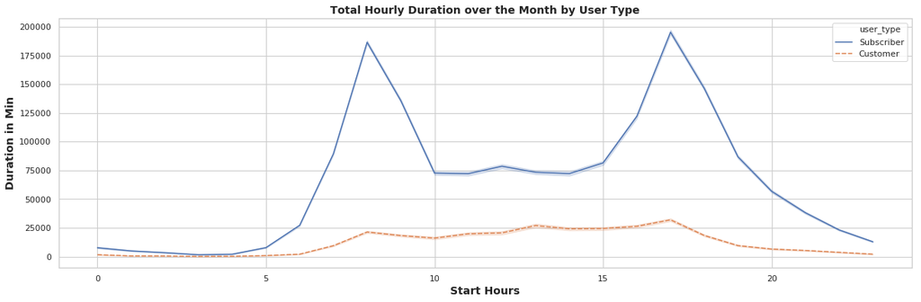

### How do customers perform by the day

- Although Subscriber users are much more than Customer user, but they have less average duration ride compared to Customer users. This could be due to the reason why every user is renting the bike. Subscribers are likely to be renting the bike for specific reason like going to work while Customers are renting bikes for pleasure especially on weekends

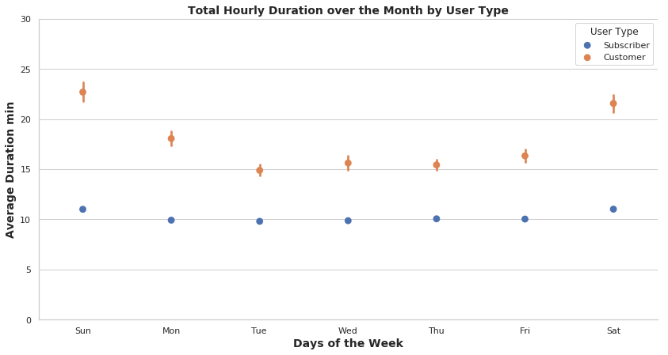

### By the hours of the day, how do users perform duration wise

- A couple of data points around 3am are seen to record average duration over close to 175 mins (~ 3hrs). This accounts for the high deviation that was observed in the previous plot

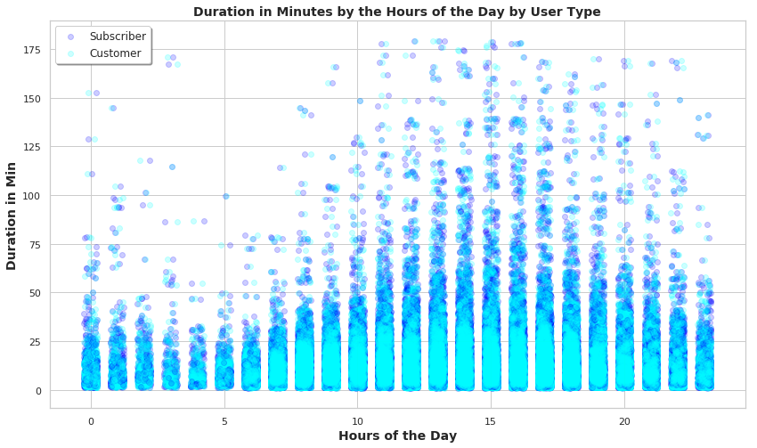

## Conclusions

[output not shown]